# Diabetes Care_SVM

Shan Wang

11 February, 2020

# 1 Loading and Exploring the Data Set

Let us first read the data set from the file.

```r
quality = read.csv("Diabetes.csv")
str(quality)
```

```
## 'data.frame':    131 obs. of  14 variables:
##  $ MemberID            : int  1 2 3 4 5 6 7 8 9 10 ...
##  $ InpatientDays       : int  0 1 0 0 8 2 16 2 2 4 ...
##  $ ERVisits            : int  0 1 0 1 2 0 1 0 1 2 ...
##  $ OfficeVisits        : int  18 6 5 19 19 9 8 8 4 0 ...
##  $ Narcotics           : int  1 1 3 0 3 2 1 0 3 2 ...
##  $ DaysSinceLastERVisit: num  731 411 731 158 449 ...
##  $ Pain                : int  10 0 10 34 10 6 4 5 5 2 ...
##  $ TotalVisits         : int  18 8 5 20 29 11 25 10 7 6 ...
##  $ ProviderCount       : int  21 27 16 14 24 40 19 11 28 21 ...
##  $ MedicalClaims       : int  93 19 27 59 51 53 40 28 20 17 ...
##  $ ClaimLines          : int  222 115 148 242 204 156 261 87 98 66 ...
##  $ StartedOnCombination: logi  FALSE FALSE FALSE FALSE FALSE FALSE ...
##  $ AcuteDrugGapSmall   : int  0 1 5 0 0 4 0 0 0 0 ...
##  $ PoorCare            : int  0 0 0 0 0 1 0 0 1 0 ...
```

*MemberID* is the unique identifier that numbers patients from 1 to 131. *InpatientDays* is the number of inpatient visits or the number of days that the patient spent in the hospital. *ERVisits* is the number of times the patient visited the emergency room. *OfficeVisits* is the number of times that the patient visited any doctor’s office. *Narcotics* is the number of prescriptions that the patient had for narcotics. *DaysSinceLastERVisit* is the number of days between the patient’s last emergency room (ER) visit and the end of the study period, and it is set to the length of the study period if they never visited the ER. *Pain* is the number of visits for which the patient complained about pain. *TotalVisits* is the total number of times the patient visited any healthcare provider. *ProviderCount* is the number of providers that served the patient. *MedicalClaims* is the number of days on which the patient had a medical claim. *ClaimLines* is the total number of medical claims. *StartedOnCombination* is whether or not the patient was started on a combination of drugs to treat their diabetes. *AcuteDrugGapSmall* is the fraction of acute drugs that were refilled quickly after the prescription ran out. *PoorCare* is the dependent variable, and is equal to 1 if the patient had poor care, and equal to 0 if the patient had good care.

The propotion of poor care.

```r
percPC = sum(quality$PoorCare)/nrow(quality)
percPC
```

```
## [1] 0.2519084
```

In SVM model, wo need the value of dependent variable to be -1 or 1. Change Poorcare 0 to Poorcare -1

```r
quality$PoorCare[which(quality$PoorCare==0)]=-1
```

Change Poorcare to factor variable.

```r
quality$PoorCare=as.factor(quality$PoorCare)
str(quality$PoorCare)
```

```
##  Factor w/ 2 levels "-1","1": 1 1 1 1 1 2 1 1 2 1 ...
```

```r
table(quality$PoorCare)
```

```
##
## -1  1
## 98 33
```

# 2 Baseline Model for Predicting Patients Receiving Good Care

The baseline model for such a classification problem is to just predict the most frequent outcome for all observations. Since good care is more common than poor care, we would predict that all patients are receiving good care, which gives us an accuracy of 74.81%.

Last lecture, we used Logistic Regression model, and the out-of-sample accuracy of the model with threshold 0.3 is 79.49%.

# 3 Splitting the Data Set for Training and Testing

```r
library(caTools)
```

```r
set.seed(123)
split = sample.split(quality$PoorCare, SplitRatio = 0.70)
```

```r
qualityTrain = subset(quality, split == TRUE)
qualityTest = subset(quality, split == FALSE)
```

```r
table(qualityTrain$PoorCare)
```

```
##
## -1  1
## 69 23
```

```r
table(qualityTest$PoorCare)
```

```
##
## -1  1
## 29 10
```

# 4 Building a SVM model

Now, we are ready to build a SVM model using *OfficeVisits* and *Narcotics* as independent variables, consistent with last lecture. Before that, let us reduce the unuseful variables.

```r
Train=qualityTrain[,c(4,5,14)]
Test=qualityTest[,c(4,5,14)]
```

let us plot the *OfficeVisits* and *Narcotics* with *PoorcCare*.

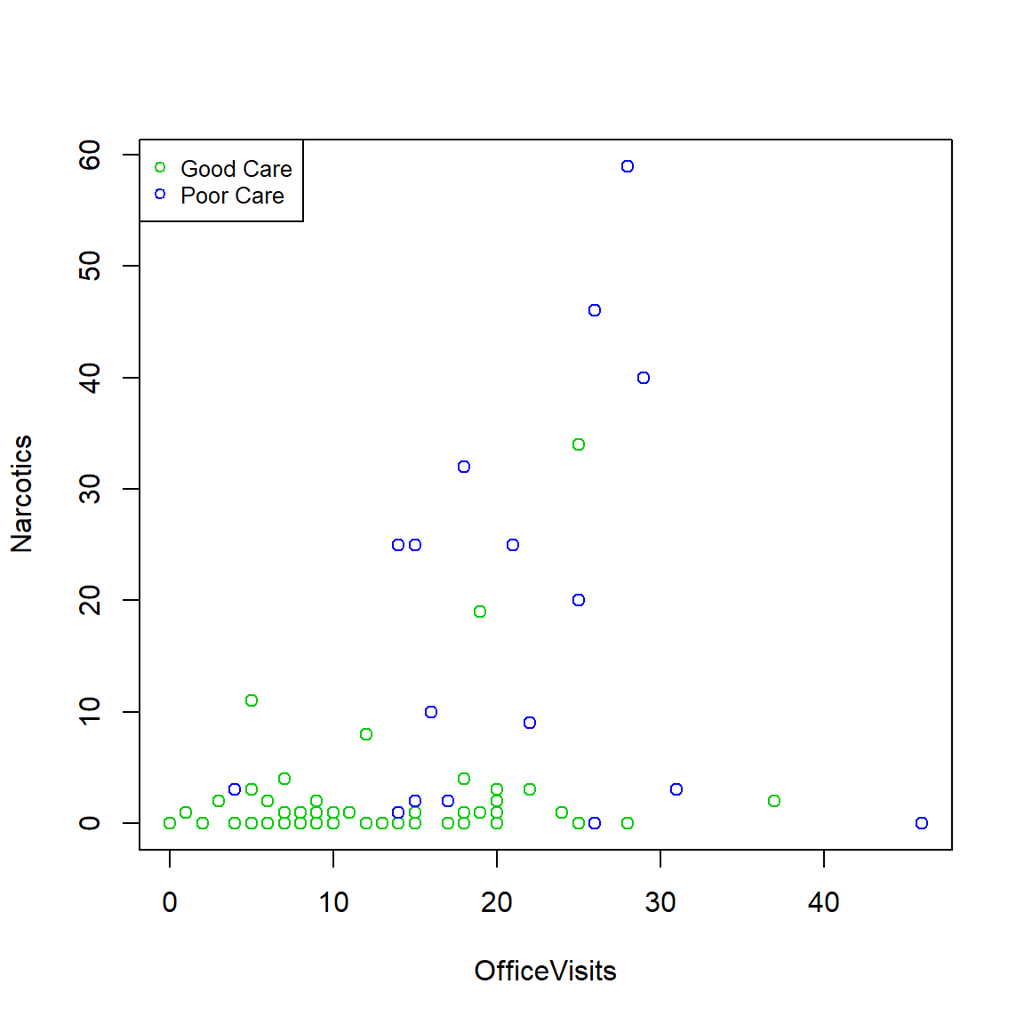

```r
plot(Train[,c(-3)], col=(2+as.numeric(Train[,3])))
legend("topleft", legend=c("Good Care", "Poor Care"),     col=3:4, pch=1, cex=0.8)
```

To build SVM model, we need the package *e1071*. This package covers functions for latent class analysis, short time Fourier transform, fuzzy clustering, support vector machines, shortest path computation, bagged clustering, naive Bayes classifier, etc. Let us load it (install it by yourself).

```r
library(e1071)
```

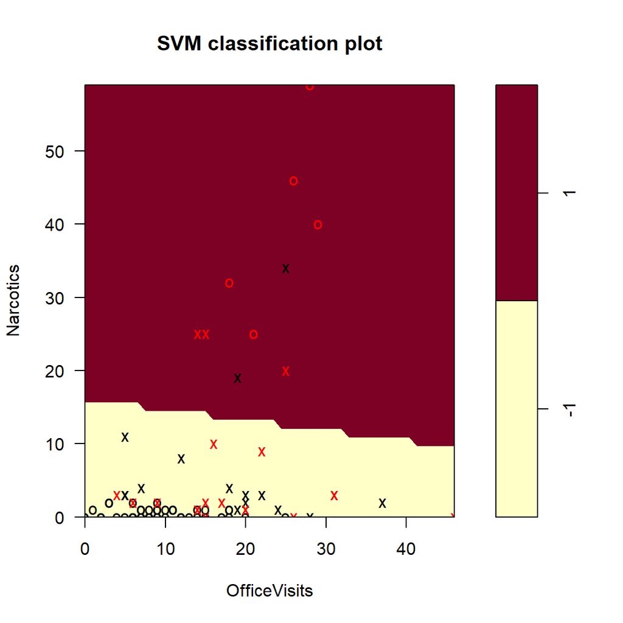

```r
svmfit=svm(PoorCare ~Narcotics+ OfficeVisits, data=Train, kernel="linear", cost=10)
plot(svmfit, Train)
```

List the support vectors by *svmfit$index*:

```r
svmfit$index
```

```
##  [1]  2  7  8  9 10 23 34 40 41 44 45 65 66 76 78 81 89 92  3  6 13 15 18
## [24] 27 31 38 42 58 68 70 72 73 75 80 91
```

```r
summary(svmfit)
```

```
##
## Call:
## svm(formula = PoorCare ~ Narcotics + OfficeVisits, data = Train,
##     kernel = "linear", cost = 10)
##
##
## Parameters:
##    SVM-Type:  C-classification
##  SVM-Kernel:  linear
##        cost:  10
##
## Number of Support Vectors:  35
##
##  ( 18 17 )
##
##
## Number of Classes:  2
##
## Levels:
##  -1 1
```

Let us change to a smaller value of the cost parameter:

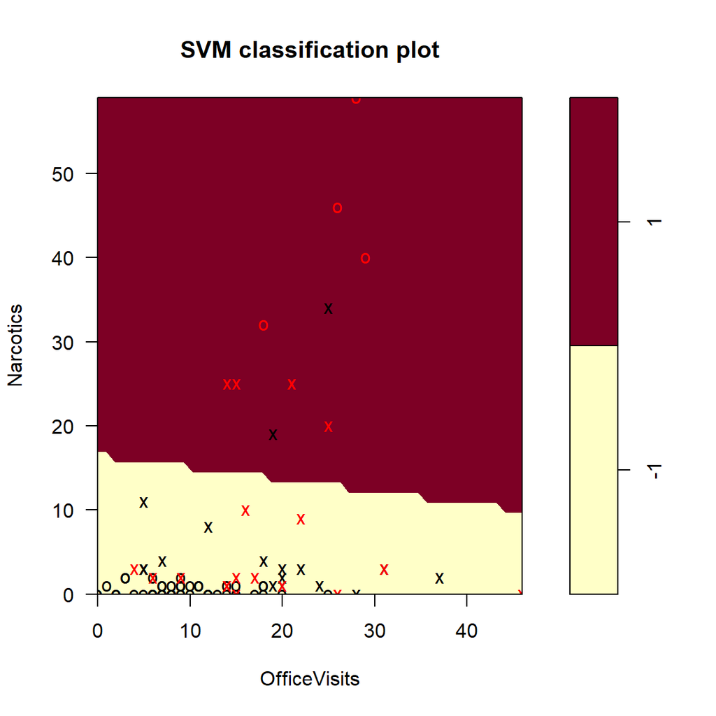

```r
svmfit=svm(PoorCare ~Narcotics+ OfficeVisits, data=Train, kernel="linear", cost=1)
plot(svmfit, Train)
```

Let us change to a RBF kernel:

*gamma* can be regarded as the inverse of the sigma: *exp(-gamma|x-z|^2)*

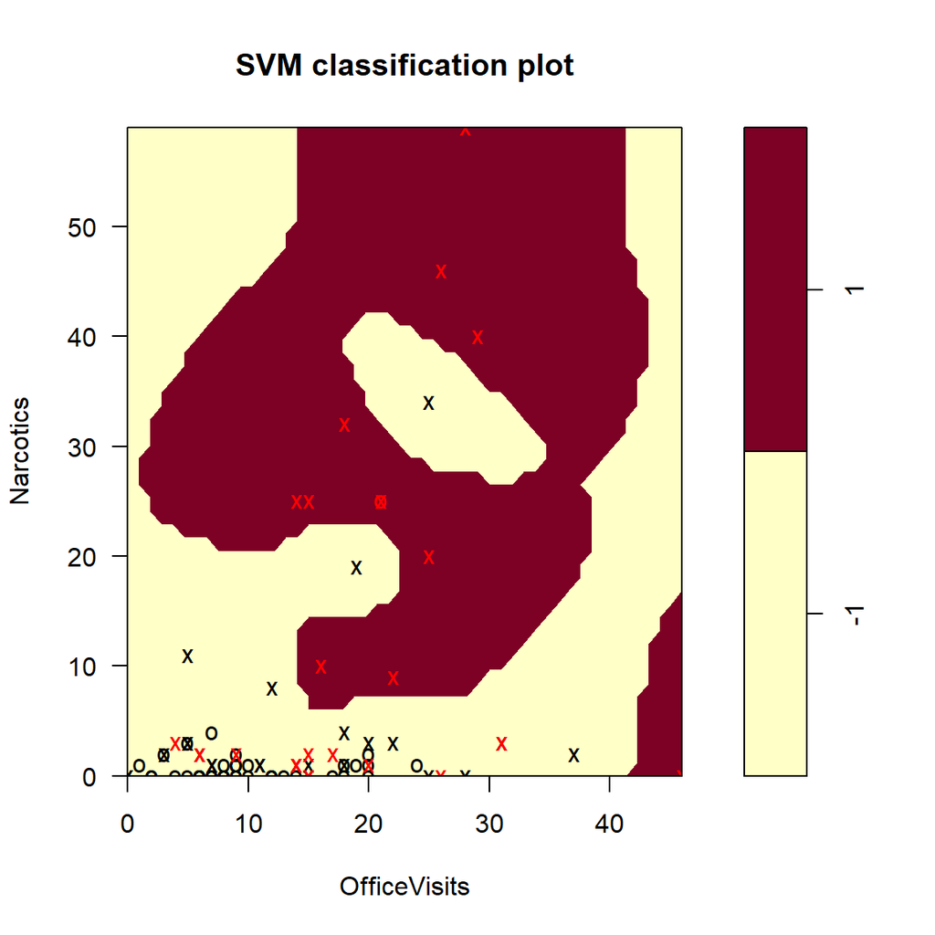

```r
svmfit=svm(PoorCare ~Narcotics+ OfficeVisits, data=Train, kernel="radial",  gamma=2, cost=10)
plot(svmfit, Train)
```

With smaller cost parameter.

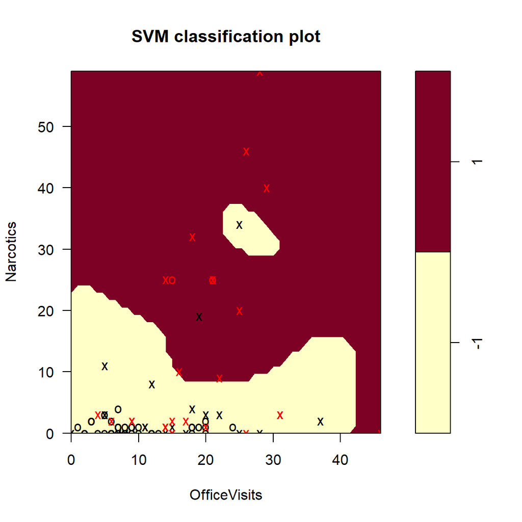

```r
svmfit=svm(PoorCare ~Narcotics+ OfficeVisits, data=Train, kernel="radial",  gamma=2, cost=1)
plot(svmfit, Train)
```

More on *kernel* and parameters can be found by *?svm*

# 5 In-Sample Cross Validation

*tune()* function can help us tune the parameters like *cost*, *kernel*, *gamma* etc from a set of choices. It may take a lot of time.

```r
set.seed(123)
tune.out=tune(svm,PoorCare ~Narcotics+ OfficeVisits, data=Train, scale=TRUE, ranges=list(kernel=c("radial","polynomial","sigmoid"),cost=c(0.1,0.2,0.3,0.4,0.5,0.6,0.7,0.8,0.9,1),gamma=c(0.025,0.05,0.075,0.1,0.2,0.3,0.5,0.6,0.7,0.8,0.9,1,1.2)))
bestmod=tune.out$best.model
summary(bestmod)
```

```
##
## Call:
## best.tune(method = svm, train.x = PoorCare ~ Narcotics + OfficeVisits,
##     data = Train, ranges = list(kernel = c("radial", "polynomial",
##         "sigmoid"), cost = c(0.1, 0.2, 0.3, 0.4, 0.5, 0.6, 0.7,
##         0.8, 0.9, 1), gamma = c(0.025, 0.05, 0.075, 0.1, 0.2,
##         0.3, 0.5, 0.6, 0.7, 0.8, 0.9, 1, 1.2)), scale = TRUE)
##
##
## Parameters:
##    SVM-Type:  C-classification
##  SVM-Kernel:  sigmoid
##        cost:  0.5
##      coef.0:  0
##
## Number of Support Vectors:  41
##
##  ( 21 20 )
##
##
## Number of Classes:  2
##
## Levels:
##  -1 1
```

The K-fold cross validation will randomly pick 1 of K sets of data points from training data set K times. So the output best model may change every time if we do not fix the seed of random number.

Plot the best model:

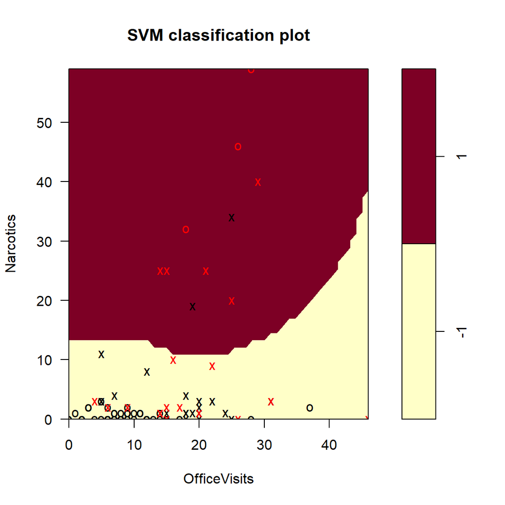

```r
plot(bestmod, Train)
```

And we get the following confusion matrix with the best model.

```r
predictTrain = predict(bestmod, type = "response")
conf1=table(Train$PoorCare, predictTrain)
conf1
```

```
##     predictTrain
##      -1  1
##   -1 67  2
##   1  14  9
```

The in-sample accuracy is 76/92 = 82.61%.

# 6 Out-of-Sample Model Testing

Similarly, we can perform the out-of-sample test for our model using the test data set. We firstly plot the data in test set:

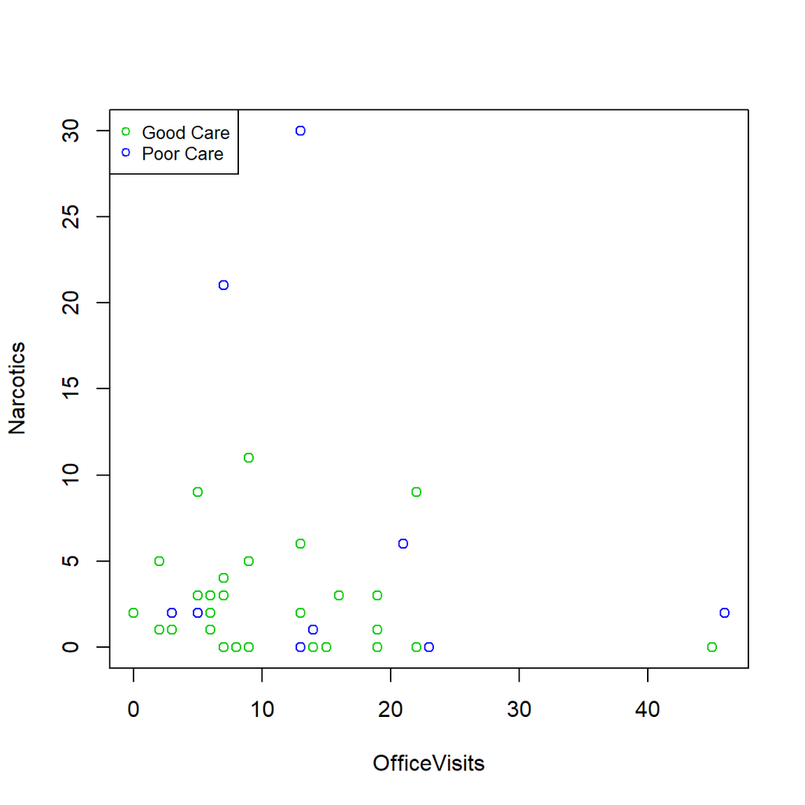

```r
plot(Test[,c(-3)], col=(2+as.numeric(Test[,3])))
legend("topleft", legend=c("Good Care", "Poor Care"),     col=3:4, pch=1, cex=0.8)
```

And we get the following confusion matrix with the best model for new prediction.

```r
predictTest = predict(bestmod, type = "response", newdata = Test)
conf2=table(Test$PoorCare, predictTest)
conf2
```

```
##     predictTest
##      -1  1
##   -1 29  0
##   1   8  2
```

The out-of-sample accuracy of the best model is 31/39 = 79.49%. For this sepecific data set, SVM has same performance as logistic rgression.